# Behavioral Data Science Project - Part II

Avisek Choudhury Ben Corriveau Cindy Nikolai

11/06/2020

## Part A - Question 3

Free-response comments, either good or bad, were collected in addition to the 14-item quantitative survey. The executives are not quite sure how to examine it without going through individual surveys one by one, but they want you to see if there are any concepts or insights that arise from these responses. Do the free responses relate to the findings in a) or b) at all?

```r
#Import the libraries
library(tidyverse)
library(haven)
library(plotly)
library(reshape2)
library(tidytext)
library(wordcloud2)
library(sentimentr)
library(lexicon)
library(magrittr)
library(tidyr)

#Read the data set
sfoDf <- read_delim('C:/MSDS/Fall 2020/Behavioral Data Science/Project/SFO_survey_withText.txt', delim="\t")
head(sfoDf)
```

```
## # A tibble: 6 x 101
##   RESPNUM CCGID  TERM STRATA ATYPE AIRLINE  DEST GATENUM INTDATE    Q1  Q2_1
##     <dbl> <dbl> <dbl>  <dbl> <dbl>   <dbl> <dbl>   <dbl>   <dbl> <dbl> <dbl>
## 1       1   150     1      2     1      25     1      21       2     2     3
## 2       2   151     1      2     1      25     1      21       2     2     4
## 3       3   152     1      2     1      25     1      21       2     2     1
## 4       4   153     1      2     1      25     1      21       2     2     5
## 5       5   154     1      2     1      25     1      21       2     1     2
## 6       6   155     1      2     1      25     1      21       2     2     3
## # ... with 90 more variables: Q2_2 <dbl>, Q2_3 <dbl>, Q2_4 <dbl>, Q2_5 <lgl>,
## #   Q2_6 <lgl>, Q3_1 <dbl>, Q3_2 <dbl>, Q3_3 <dbl>, Q3_4 <lgl>, Q3_5 <lgl>,
## #   Q3_6 <lgl>, Q3A <dbl>, Q4A <dbl>, Q4B <dbl>, Q4C <dbl>, Q5 <dbl>,
## #   Q5AVG <dbl>, SAQ <dbl>, Q6A <dbl>, Q6B <dbl>, Q6C <dbl>, Q6D <dbl>,
## #   Q6E <dbl>, Q6F <dbl>, Q6G <dbl>, Q6H <dbl>, Q6I <dbl>, Q6J <dbl>,
## #   Q6K <dbl>, Q6L <dbl>, Q6M <dbl>, Q6N <dbl>, Q7COM1 <dbl>, Q7COM2 <dbl>,
## #   Q7COM3 <dbl>, Q7A1 <dbl>, Q7A2 <dbl>, Q7A3 <dbl>, Q8A <dbl>, Q8B <dbl>,
## #   Q8C <dbl>, Q8D <dbl>, Q8E <dbl>, Q8F <dbl>, Q8COM1 <dbl>, Q8COM2 <dbl>,
## #   Q8COM3 <lgl>, Q9 <dbl>, Q9APOS1 <dbl>, Q9APOS2 <dbl>, Q9APOS3 <dbl>,
## #   Q9ANEG1 <dbl>, Q9ANEG2 <lgl>, Q9ANEG3 <lgl>, Q9ANTR1 <dbl>, Q9ANTR2 <dbl>,
## #   Q9ANTR3 <lgl>, Q10 <dbl>, Q11 <dbl>, Q11A1 <dbl>, Q11A2 <dbl>, Q11A3 <dbl>,
## #   Q12 <dbl>, Q13A <dbl>, Q13B <dbl>, Q13_COM <lgl>, Q13COM1 <dbl>,
## #   Q13COM2 <dbl>, Q13COM3 <lgl>, Q14 <dbl>, Q14A <lgl>, Q14A1 <dbl>,
## #   Q14A2 <dbl>, Q14A3 <dbl>, Q15 <dbl>, SFFLAG <dbl>, COUNTRY <dbl>,
## #   Q17 <dbl>, AGE <dbl>, Q18 <dbl>, Q19 <dbl>, INC <dbl>, MAIL <dbl>,
## #   LANG <dbl>, DESTMARK <dbl>, DESTINATION <chr>, DESTGEO <dbl>, WEIGHT <dbl>,
## #   Location.1 <lgl>, Q7_text_All <chr>
```

```r
#Count the NA or missing Rows for each columns
sapply(sfoDf, function(x) sum(is.na(x)))
```

```
##     RESPNUM       CCGID        TERM      STRATA       ATYPE     AIRLINE
##           0           0           0           0           0           0
##        DEST     GATENUM     INTDATE          Q1        Q2_1        Q2_2
##           0           0           0           9           0          69
##        Q2_3        Q2_4        Q2_5        Q2_6        Q3_1        Q3_2
##        3140        3226        3234        3234           0           3
##        Q3_3        Q3_4        Q3_5        Q3_6         Q3A         Q4A
##        3225        3234        3234        3234          23         128
##         Q4B         Q4C          Q5       Q5AVG         SAQ         Q6A
##         277         224          27          27           0         103
##         Q6B         Q6C         Q6D         Q6E         Q6F         Q6G
##          81         106          79          74          79         113
##         Q6H         Q6I         Q6J         Q6K         Q6L         Q6M
##         115         144         182         190         214         216
##         Q6N      Q7COM1      Q7COM2      Q7COM3        Q7A1        Q7A2
##         112        1715        2675        3056        3164        3194
##        Q7A3         Q8A         Q8B         Q8C         Q8D         Q8E
##        3219          48         147         150         177         116
##         Q8F      Q8COM1      Q8COM2      Q8COM3          Q9     Q9APOS1
##          69        3137        3229        3234          48        2275
##     Q9APOS2     Q9APOS3     Q9ANEG1     Q9ANEG2     Q9ANEG3     Q9ANTR1
##        3098        3223        3215        3234        3234        3084
##     Q9ANTR2     Q9ANTR3         Q10         Q11       Q11A1       Q11A2
##        3220        3234         107        2782        3005        3165
##       Q11A3         Q12        Q13A        Q13B     Q13_COM     Q13COM1
##        3223           0          94         210        3234        2886
##     Q13COM2     Q13COM3         Q14        Q14A       Q14A1       Q14A2
##        3214        3234         104        3234        2919        3194
##       Q14A3         Q15      SFFLAG     COUNTRY         Q17         AGE
##        3229          87           0         178          95          95
##         Q18         Q19         INC        MAIL        LANG    DESTMARK
##         186         651         651           0           0           0
## DESTINATION     DESTGEO      WEIGHT  Location.1 Q7_text_All
##           0           0           0        3234        1677
```

We see lot of columns with huge no of missing values. Let’s check the columns with more than 50% values are missing.

```r
#Count the NA or missing Rows for each columns
unlist(sapply(sfoDf, function(x) {
  if (sum(is.na(x)) > length(x)* 0.5)
    return (sum(is.na(x)))
  }))
```

```
##        Q2_3        Q2_4        Q2_5        Q2_6        Q3_3        Q3_4
##        3140        3226        3234        3234        3225        3234
##        Q3_5        Q3_6      Q7COM1      Q7COM2      Q7COM3        Q7A1
##        3234        3234        1715        2675        3056        3164
##        Q7A2        Q7A3      Q8COM1      Q8COM2      Q8COM3     Q9APOS1
##        3194        3219        3137        3229        3234        2275
##     Q9APOS2     Q9APOS3     Q9ANEG1     Q9ANEG2     Q9ANEG3     Q9ANTR1
##        3098        3223        3215        3234        3234        3084
##     Q9ANTR2     Q9ANTR3         Q11       Q11A1       Q11A2       Q11A3
##        3220        3234        2782        3005        3165        3223
##     Q13_COM     Q13COM1     Q13COM2     Q13COM3        Q14A       Q14A1
##        3234        2886        3214        3234        3234        2919
##       Q14A2       Q14A3  Location.1 Q7_text_All
##        3194        3229        3234        1677
```

Now convert the columns for age, income and sex.

```r
#Convert the Sex
sfoDf['Gender'] <- ifelse(sfoDf$Q18 == 1, "Male",
                          ifelse(sfoDf$Q18 == 2, "Female", "Blank"))
#Convert the Age Group column
sfoDf['Age_Group'] <- ifelse(sfoDf$Q17 == 1, "Under 18",
       ifelse(sfoDf$Q17 == 2, "18-24",
              ifelse(sfoDf$Q17 == 3, "25-34",
                     ifelse(sfoDf$Q17 == 4, "35-44",
                            ifelse(sfoDf$Q17 == 5, "45-54",
                                   ifelse(sfoDf$Q17 == 6, "55-64",
                                          ifelse(sfoDf$Q17 == 7, "65 and Over",
                                                ifelse(sfoDf$Q17 == 8, "Don't Know/Refused",
                                                       ifelse(sfoDf$Q17 == 0, "Blank", "NA")))))))))

#Convert the Income Column
sfoDf['Income'] <- ifelse(sfoDf$Q19 == 1, "Under $50,000",
                          ifelse(sfoDf$Q19 == 2, "$50,000-$100,00",
                                 ifelse(sfoDf$Q19 == 3, "$100,001-$150,000",
                                        ifelse(sfoDf$Q19 == 4, "Over $150,000",
                                               ifelse(sfoDf$Q19 == 5, "Other", "Blank")))))
```

For sentiment analysis let’s have a look at the combined comment column in the given dataset.

```r
#Comment Column
sfoDf$Q7_text_All %>%
  na.omit %>%
  head(10)
```

```
##  [1] " Airport Layout-Terminals too far away/confusing/too difficult/takes too long to get around airport/no way to get between terminals after getting through security/domestic airlines in international terminal  Smoking areas-more needed/inconveniently located  Add traffic delays/other informat…
##  [2] " Food too expensive  Positive comment about wifi  Security/Customs lines/procedures long/inefficient/ineffective"
##  [3] " Signage outside airport confusing/hard to get to airport/difficult to find correct terminal"
##  [4] " Security/Customs lines/procedures long/inefficient/ineffective  Signage inside airport confusing/small/hard to find gate or airline"
##  [5] " Security/Customs lines/procedures long/inefficient/ineffective"
##  [6] " General cleanliness neg comment  Need more artwork/exhibitions/change artwork more frequently"
##  [7] " Wifi-not free long enough/difficult to access/doesn’t cover entire airport/overloaded/didn’t know was available"
##  [8] " Signage inside airport confusing/small/hard to find gate or airline"
##  [9] " Signage inside airport confusing/small/hard to find gate or airline  Signage outside airport confusing/hard to get to airport/difficult to find correct terminal  Need Starbucks/Peets/coffee house type restaurants (both before and after security)   Security/Customs lines/procedures long/ine…
## [10] " Security/Customs lines/procedures long/inefficient/ineffective"
```

Let’s remove the forward slash and hyphens from the comments and replace that with blank space.

```r
#Remove the Slash
sfoDf$Q7_text_All <- gsub(pattern = "/",
                          replacement = " ",
                          sfoDf$Q7_text_All)
#Remove the hyphens
sfoDf$Q7_text_All <- gsub(pattern = "-",
                          replacement = " ",
                          sfoDf$Q7_text_All)
#Verify the data
sfoDf$Q7_text_All %>%
  na.omit %>%
  head(10)
```

```
##  [1] " Airport Layout Terminals too far away confusing too difficult takes too long to get around airport no way to get between terminals after getting through security domestic airlines in international terminal  Smoking areas more needed inconveniently located  Add traffic delays other informat…
##  [2] " Food too expensive  Positive comment about wifi  Security Customs lines procedures long inefficient ineffective"
##  [3] " Signage outside airport confusing hard to get to airport difficult to find correct terminal"
##  [4] " Security Customs lines procedures long inefficient ineffective  Signage inside airport confusing small hard to find gate or airline"
##  [5] " Security Customs lines procedures long inefficient ineffective"
##  [6] " General cleanliness neg comment  Need more artwork exhibitions change artwork more frequently"
##  [7] " Wifi not free long enough difficult to access doesn’t cover entire airport overloaded didn’t know was available"
##  [8] " Signage inside airport confusing small hard to find gate or airline"
##  [9] " Signage inside airport confusing small hard to find gate or airline  Signage outside airport confusing hard to get to airport difficult to find correct terminal  Need Starbucks Peets coffee house type restaurants (both before and after security)   Security Customs lines procedures long ine…
## [10] " Security Customs lines procedures long inefficient ineffective"
```

Let’s check the count of distinct words used by each age group. We can remove the stop words before do the count.

```r
#Word Count by each Inmate
wordDf <- sfoDf %>%
  select(Q7_text_All, Q17, Age_Group) %>%
   rename(Age = Q17,
         Comments = Q7_text_All) %>%
  unnest_tokens(word, Comments) %>%
  anti_join(stop_words) %>%
  na.omit() %>%
  group_by(Age_Group, Age, word) %>%
  summarise(count = n())
#Check the data set
head(wordDf, n = 20)
```

```
## # A tibble: 20 x 4
## # Groups:   Age_Group, Age [1]
##    Age_Group   Age word          count
##    <chr>     <dbl> <chr>         <int>
##  1 18-24         2 ac                2
##  2 18-24         2 access            5
##  3 18-24         2 air               3
##  4 18-24         2 airline          11
##  5 18-24         2 airlines          4
##  6 18-24         2 airport          43
##  7 18-24         2 airtrain          4
##  8 18-24         2 amenities         9
##  9 18-24         2 announcements     1
## 10 18-24         2 artwork           6
## 11 18-24         2 atm’s             3
## 12 18-24         2 bad               3
## 13 18-24         2 bart              3
## 14 18-24         2 bilingual         1
## 15 18-24         2 booth             1
## 16 18-24         2 bring             1
## 17 18-24         2 business          5
## 18 18-24         2 carts             1
## 19 18-24         2 chain             8
## 20 18-24         2 change            9
```

Let’s count positive and negative words for each age group and calculate the sentiment.

```r
#Count positive and negative words
wordSent_bing <- wordDf %>%
  inner_join(get_sentiments("bing")) %>%
  group_by(Age_Group, Age, sentiment) %>%
  count(sentiment)  %>%
  spread(sentiment, n, fill = 0) %>%
  mutate(sentiment = positive - negative)
#Print the dataset
head(wordSent_bing, n= 10)
```

```
## # A tibble: 8 x 5
## # Groups:   Age_Group, Age [8]
##   Age_Group            Age negative positive sentiment
##   <chr>              <dbl>    <dbl>    <dbl>     <dbl>
## 1 18-24                  2       16       10        -6
## 2 25-34                  3       17       11        -6
## 3 35-44                  4       18       11        -7
## 4 45-54                  5       19       12        -7
## 5 55-64                  6       18       11        -7
## 6 65 and Over            7       18       11        -7
## 7 Don't Know/Refused     8        3        1        -2
## 8 Under 18               1        1        1         0
```

Let’s plot the positive and negative sentient count for each age group .

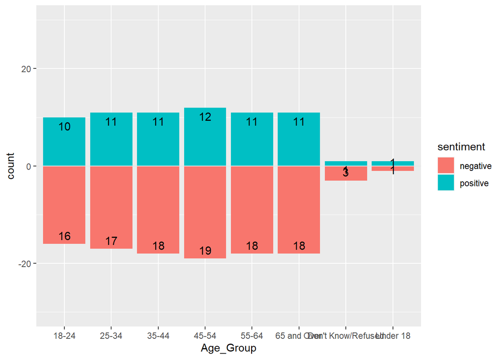

```r
#Generate the Dataset for the Plot
plotDf <- wordDf %>%
  inner_join(get_sentiments("bing")) %>%
  group_by(Age_Group, Age, sentiment) %>%
  count(sentiment) %>%
  rename(count = n)
#Generate the Barplot for the Positive/Negative Sentiment
#For Each Age Group
ggplot(plotDf, aes(Age_Group), ylim(-30:30)) +
geom_bar(data = subset(plotDf, sentiment == "positive"),
   aes(y = count, fill = sentiment), stat = "identity", position = "dodge") +
geom_bar(data = subset(plotDf, sentiment == "negative"),
   aes(y = -count, fill = sentiment), stat = "identity", position = "dodge") +
geom_hline(yintercept = 0,colour = "grey90") +
  #Now Add the Tect to it
geom_text(data = subset(plotDf, sentiment == "positive"),
      aes(Age_Group, count, group=sentiment, label=count),
        position = position_dodge(width=0.9), vjust = 1.5, size=4) +
geom_text(data = subset(plotDf, sentiment == "negative"),
      aes(Age_Group, -count, group=sentiment, label=count),
        position = position_dodge(width=0.9), vjust = -.5, size=4) +
    coord_cartesian(ylim = c(-30, 30))
```

Now instead of `bing` we can use `affin` which assigns a value positive/negative to each word and calculate the average sentiment for age group we have.

```r
#Calculate Average sentiment for each inmate
avgSentAgeGrp <- wordDf %>%
  inner_join(get_sentiments("afinn")) %>%
  group_by(Age_Group) %>%
  summarise( totalWords = sum(count), sentSum = sum(value)) %>%
  mutate(Avg_Sentiment = sentSum / totalWords)
#Print the dataset
head(avgSentAgeGrp, n=20)
```

```
## # A tibble: 8 x 4
##   Age_Group          totalWords sentSum Avg_Sentiment
##   <chr>                   <int>   <dbl>         <dbl>
## 1 18-24                     105      -8       -0.0762
## 2 25-34                     402      -7       -0.0174
## 3 35-44                     337     -11       -0.0326
## 4 45-54                     366     -12       -0.0328
## 5 55-64                     358     -11       -0.0307
## 6 65 and Over               236      -8       -0.0339
## 7 Don't Know/Refused          3      -4       -1.33
## 8 Under 18                    8       2        0.25
```

Here also we see the average sentiment is negative almost all age range except the population under 18.

Now let’s analyze the sentiments by gender.

```r
#Word Count by each Inmate
wordDf <- sfoDf %>%
  select(Gender,  Q7_text_All) %>%
   rename(Comments = Q7_text_All) %>%
  unnest_tokens(word, Comments) %>%
  anti_join(stop_words) %>%
  na.omit() %>%
  group_by(Gender, word) %>%
  summarise(count = n())
#Check the data set
head(wordDf, n = 20)
```

```
## # A tibble: 20 x 3
## # Groups:   Gender [1]
##    Gender word          count
##    <chr>  <chr>         <int>
##  1 Female ac                5
##  2 Female access           25
##  3 Female air              13
##  4 Female airline          98
##  5 Female airlines         64
##  6 Female airport         323
##  7 Female airtrain         19
##  8 Female allowed           3
##  9 Female amenities        64
## 10 Female announcements    15
## 11 Female artwork          50
## 12 Female atm’s            19
## 13 Female automated         1
## 14 Female bad              13
## 15 Female baggage           3
## 16 Female bart             25
## 17 Female bilingual        15
## 18 Female booth            26
## 19 Female bring             4
## 20 Female business         22
```

Let’s count positive and negative words for each sex and calculate the sentiment.

```r
#Count positive and negative words
wordSent_bing <- wordDf %>%
  inner_join(get_sentiments("bing")) %>%
  group_by(Gender, sentiment) %>%
  count(sentiment)  %>%
  spread(sentiment, n, fill = 0) %>%
  mutate(sentiment = positive - negative)
#Print the dataset
head(wordSent_bing, n= 10)
```

```
## # A tibble: 2 x 4
## # Groups:   Gender [2]
##   Gender negative positive sentiment
##   <chr>     <dbl>    <dbl>     <dbl>
## 1 Female       19       12        -7
## 2 Male         18       12        -6
```

The sentiment is negative for both males and females. Let’s plot the data we generated above.

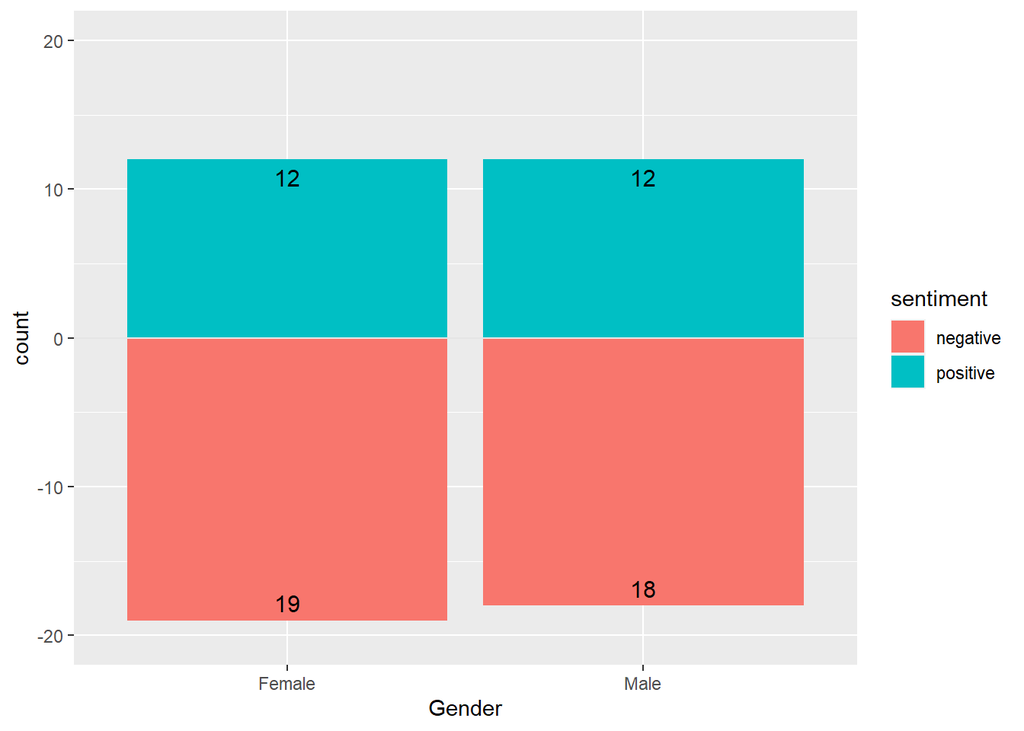

```r
#Generate the Dataset for the Plot
plotDf <- wordDf %>%
  inner_join(get_sentiments("bing")) %>%
  group_by(Gender, sentiment) %>%
  count(sentiment) %>%
  rename(count = n)
#Generate the Barplot for the Positive/Negative Sentiment
#For Each Age Group
ggplot(plotDf, aes(Gender), ylim(-20:20)) +
geom_bar(data = subset(plotDf, sentiment == "positive"),
   aes(y = count, fill = sentiment), stat = "identity", position = "dodge") +
geom_bar(data = subset(plotDf, sentiment == "negative"),
   aes(y = -count, fill = sentiment), stat = "identity", position = "dodge") +
geom_hline(yintercept = 0,colour = "grey90") +
  #Now Add the Tect to it
geom_text(data = subset(plotDf, sentiment == "positive"),
      aes(Gender, count, group=sentiment, label=count),
        position = position_dodge(width=0.9), vjust = 1.5, size=4) +
geom_text(data = subset(plotDf, sentiment == "negative"),
      aes(Gender, -count, group=sentiment, label=count),
        position = position_dodge(width=0.9), vjust = -.5, size=4) +
    coord_cartesian(ylim = c(-20, 20))
```

Let’s use `affin` again and calculate the average sentiment for each sex.

```r
#Calculate Average sentiment for each inmate
avgSentSex <- wordDf %>%
  inner_join(get_sentiments("afinn")) %>%
  group_by(Gender) %>%
  summarise( totalWords = sum(count), sentSum = sum(value)) %>%
  mutate(Avg_Sentiment = sentSum / totalWords)
#Print the dataset
head(avgSentSex, n=20)
```

```
## # A tibble: 2 x 4
##   Gender totalWords sentSum Avg_Sentiment
##   <chr>       <int>   <dbl>         <dbl>
## 1 Female        832     -12      -0.0144
## 2 Male          959      -9      -0.00938
```

Let’s check the count of distinct words used by each income group and remove the stop words before do the count.

```r
#Word Count by each Inmate
wordDf <- sfoDf %>%
  select(Q7_text_All, Income) %>%
   rename(Comments = Q7_text_All) %>%
  unnest_tokens(word, Comments) %>%
  anti_join(stop_words) %>%
  na.omit() %>%
  group_by(Income, word) %>%
  summarise(count = n())
#Check the data set
head(wordDf, n = 20)
```

```
## # A tibble: 20 x 3
## # Groups:   Income [1]
##    Income            word          count
##    <chr>             <chr>         <int>
##  1 $100,001-$150,000 ac                1
##  2 $100,001-$150,000 access           12
##  3 $100,001-$150,000 air               3
##  4 $100,001-$150,000 airline          35
##  5 $100,001-$150,000 airlines         11
##  6 $100,001-$150,000 airport         116
##  7 $100,001-$150,000 airtrain          8
##  8 $100,001-$150,000 amenities        21
##  9 $100,001-$150,000 announcements     2
## 10 $100,001-$150,000 artwork          12
## 11 $100,001-$150,000 atm’s             7
## 12 $100,001-$150,000 bad               3
## 13 $100,001-$150,000 baggage           3
## 14 $100,001-$150,000 bart              6
## 15 $100,001-$150,000 bilingual         2
## 16 $100,001-$150,000 booth             2
## 17 $100,001-$150,000 bring             1
## 18 $100,001-$150,000 business          7
## 19 $100,001-$150,000 car              13
## 20 $100,001-$150,000 carts             5
```

Let’s count positive and negative words for each income group and calculate the sentiment.

```r
#Count positive and negative words
wordSent_bing <- wordDf %>%
  inner_join(get_sentiments("bing")) %>%
  group_by(Income, sentiment) %>%
  count(sentiment)  %>%
  spread(sentiment, n, fill = 0) %>%
  mutate(sentiment = positive - negative)
#Print the dataset
head(wordSent_bing, n= 10)
```

```
## # A tibble: 4 x 4
## # Groups:   Income [4]
##   Income            negative positive sentiment
##   <chr>                <dbl>    <dbl>     <dbl>
## 1 $100,001-$150,000       18       11        -7
## 2 $50,000-$100,00         19       11        -8
## 3 Over $150,000           18       12        -6
## 4 Under $50,000           18       11        -7
```

The sentiment is dominantly negative for all income group.

We can plot this data as well.

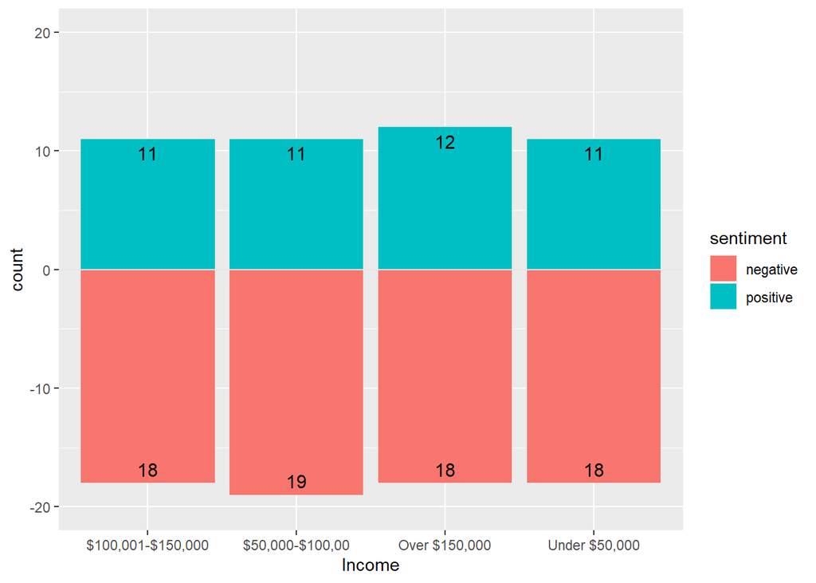

```r
#Generate the Dataset for the Plot
plotDf <- wordDf %>%
  inner_join(get_sentiments("bing")) %>%
  group_by(Income, sentiment) %>%
  count(sentiment) %>%
  rename(count = n)
#Generate the Barplot for the Positive/Negative Sentiment
#For Each Age Group
ggplot(plotDf, aes(Income), ylim(-20:20)) +
geom_bar(data = subset(plotDf, sentiment == "positive"),
   aes(y = count, fill = sentiment), stat = "identity", position = "dodge") +
geom_bar(data = subset(plotDf, sentiment == "negative"),
   aes(y = -count, fill = sentiment), stat = "identity", position = "dodge") +
geom_hline(yintercept = 0,colour = "grey90") +
  #Now Add the Tect to it
geom_text(data = subset(plotDf, sentiment == "positive"),
      aes(Income, count, group=sentiment, label=count),
        position = position_dodge(width=0.9), vjust = 1.5, size=4) +
geom_text(data = subset(plotDf, sentiment == "negative"),
      aes(Income, -count, group=sentiment, label=count),
        position = position_dodge(width=0.9), vjust = -.5, size=4) +
    coord_cartesian(ylim = c(-20, 20))
```

We can use `affin` again and calculate the average sentiment for all income groups.

```r
#Calculate Average sentiment for each inmate
avgSentIncome <- wordDf %>%
  inner_join(get_sentiments("afinn")) %>%
  group_by(Income) %>%
  summarise( totalWords = sum(count), sentSum = sum(value)) %>%
  mutate(sentiment = sentSum / totalWords)
#Print the dataset
head(avgSentIncome, n=20)
```

```
## # A tibble: 4 x 4
##   Income            totalWords sentSum sentiment
##   <chr>                  <int>   <dbl>     <dbl>
## 1 $100,001-$150,000        305     -10   -0.0328
## 2 $50,000-$100,00          476     -12   -0.0252
## 3 Over $150,000            394      -8   -0.0203
## 4 Under $50,000            321     -11   -0.0343
```